# Evaluation of the occurrence and fate of pesticides in a typical mediterranean delta ecosystem and tisk assessment for aquatic organisms

Tables and figures

# Tables

## Table 1

Median and standard deviation concentration in ng/L of the detected individual pesticides and asymmetry analysis in the investigated water samples.

| Class | Name | Median (ng/L) | Standard deviation (ng/L) | Kurtosis | Asymmetry coefficient |
| --- | --- | --- | --- | --- | --- |
| Acidics | 2,4-D | 5.1 | 103.4 | 15.2 | 3.8 |
|  | Bentazone | 34958.4 | 56966.3 | -0.1 | 1.0 |
|  | MCPA | 732.1 | 2451.3 | 2.1 | 1.7 |
| Anilides | Diflufenican | 1.0 | 6.2 | 0.3 | 1.3 |
|  | Propanil | 879.3 | 16336.9 | 5.9 | 2.4 |
| Carbamates | Methiocarb | 0.7 | 1.1 | -0.3 | 0.8 |
|  | Molinate | 15.3 | 15.7 | -1.0 | 0.5 |
|  | Triallate | 239.8 | 243.7 | 2.9 | 1.5 |
| Chloroacetanilides | Alachlor | 0.0 | 0.5 | 6.1 | 2.7 |
|  | Metolachlor | 36.2 | 17.5 | -0.2 | 0.7 |
| Dinitroaniline | Pendimethalin | 1.0 | 0.5 | -2.0 | -0.5 |
| Neonicotinoids | Acetamiprid | 60.5 | 956.5 | 12.8 | 3.4 |
|  | Imidacloprid | 50.2 | 211.4 | 3.5 | 2.1 |
|  | Thiacloprid | 0.0 | 0.8 | 2.5 | 1.9 |
| Organochlorines | 4,4'-DDD | 0.0 | 0.3 | 18.0 | 4.2 |
|  | Dicofol | 1.8 | 1.9 | -2.3 | 0.0 |
|  | Oxadiazon | 15.3 | 16.8 | -1.3 | 0.4 |
|  | Triadimefon | 1.0 | 1.4 | 1.6 | 1.1 |
| Organophosphates | Azinphos ethyl | 0.0 | 1.9 | 3.1 | 2.1 |
|  | Chlorfenviphos | 1.4 | 2.0 | 0.1 | 0.9 |
|  | Chlorpyrifos | 15.3 | 7.9 | -0.9 | -0.1 |
|  | Diazinon | 1.9 | 1.4 | -0.8 | 0.3 |
|  | Malaoxon | 0.0 | 0.2 | 7.9 | 2.8 |
| Organothiophosphates | Fenthion oxon | 0.0 | 0.8 | 2.4 | 1.8 |
|  | Fenthion oxon sulfoxide | 0.0 | 0.3 | 14.4 | 3.7 |
|  | Fenthion sulfoxide | 0.0 | 1.1 | 11.2 | 3.3 |
| Phenylureas | Chlortoluron | 0.0 | 3.6 | 9.9 | 3.2 |
|  | Diuron | 6.7 | 4.6 | -1.5 | -0.2 |
|  | Isoproturon | 0.0 | 3.0 | 18.0 | 4.2 |
|  | Linuron | 0.0 | 3.2 | 13.4 | 3.6 |
| Triazines | Atrazine | 0.0 | 0.6 | 15.4 | 3.9 |
|  | Cybutrine | 24.9 | 15.2 | -1.9 | 0.2 |
|  | Simazine | 1.5 | 2.1 | 0.8 | 1.3 |
|  | Terbuthylazine | 23.3 | 15.4 | -1.4 | -0.4 |
|  | Terbutryn | 2.6 | 1.6 | 0.7 | 0.4 |

## Table 2

Pairwise correlations values of the different pesticides detected.

|  | 2,4-D | 4,4'-DDD | Acetamiprid | Alachlor | Atrazine | Azinphos ethyl | Bentazone | Chlorfenviphos | Chlorpyrifos | Chlortoluron | Diazinon | Dicofol | Diflufenican | Diuron | Fenthion oxon | Fenthion oxon sulfoxide | Fenthion sulfoxide | Imidacloprid | Cybutrine | Isoproturon | Linuron | Malaoxon | MCPA | Methiocarb | Metolachlor | Molinate | Oxadiazon | Pendimethalin | Propanil | … |
| --- | --- | --- | --- | --- | --- | --- | --- | --- | --- | --- | --- | --- | --- | --- | --- | --- | --- | --- | --- | --- | --- | --- | --- | --- | --- | --- | --- | --- | --- | --- |
| 2,4-D | 1.00 | -0.10 | -0.12 | 0.05 | 0.06 | -0.02 | 0.19 | 0.24 | 0.18 | -0.12 | 0.26 | 0.35 | -0.07 | 0.30 | 0.61 | -0.09 | -0.08 | 0.10 | -0.22 | -0.10 | -0.04 | -0.13 | 0.04 | -0.17 | -0.30 | 0.45 | 0.36 | 0.15 | 0.15 | … |
| 4,4'-DDD | -0.10 | 1.00 | -0.06 | -0.09 | 0.11 | -0.13 | 0.29 | -0.07 | 0.37 | -0.08 | -0.37 | 0.24 | -0.17 | 0.30 | -0.13 | -0.10 | -0.10 | -0.09 | 0.29 | -0.06 | -0.09 | -0.10 | 0.07 | -0.05 | -0.07 | 0.17 | 0.18 | 0.19 | -0.13 | … |
| Acetamiprid | -0.12 | -0.06 | 1.00 | -0.16 | -0.13 | -0.02 | -0.07 | -0.15 | -0.42 | -0.15 | 0.15 | 0.10 | -0.01 | 0.30 | 0.06 | 0.00 | -0.13 | -0.09 | 0.36 | -0.11 | -0.15 | -0.06 | -0.18 | -0.05 | -0.10 | -0.26 | -0.12 | 0.17 | -0.18 | … |
| Alachlor | 0.05 | -0.09 | -0.16 | 1.00 | -0.12 | 0.33 | -0.18 | 0.52 | -0.36 | -0.12 | 0.46 | -0.02 | 0.11 | 0.07 | 0.26 | 0.78 | -0.14 | 0.36 | -0.40 | -0.09 | 0.90 | -0.14 | 0.13 | 0.41 | 0.28 | -0.36 | 0.04 | -0.44 | 0.55 | … |
| Atrazine | 0.06 | 0.11 | -0.13 | -0.12 | 1.00 | -0.17 | -0.14 | -0.23 | 0.18 | 0.84 | -0.22 | 0.33 | -0.15 | -0.20 | -0.03 | -0.13 | -0.13 | -0.17 | 0.22 | -0.08 | -0.12 | -0.13 | -0.16 | -0.27 | 0.27 | -0.13 | -0.17 | 0.26 | -0.16 | … |
| Azinphos ethyl | -0.02 | -0.13 | -0.02 | 0.33 | -0.17 | 1.00 | -0.18 | 0.79 | -0.34 | -0.17 | 0.61 | -0.07 | 0.52 | 0.14 | -0.18 | -0.06 | 0.05 | 0.43 | 0.00 | 0.31 | 0.10 | 0.51 | 0.17 | 0.76 | 0.06 | -0.18 | -0.06 | -0.04 | 0.45 | … |
| Bentazone | 0.19 | 0.29 | -0.07 | -0.18 | -0.14 | -0.18 | 1.00 | -0.05 | 0.37 | -0.32 | -0.14 | 0.11 | -0.04 | 0.53 | -0.10 | -0.28 | -0.15 | -0.02 | -0.04 | -0.22 | -0.20 | -0.26 | 0.49 | -0.19 | -0.36 | 0.46 | 0.05 | -0.11 | 0.15 | … |
| Chlorfenviphos | 0.24 | -0.07 | -0.15 | 0.52 | -0.23 | 0.79 | -0.05 | 1.00 | -0.37 | -0.28 | 0.84 | -0.28 | 0.55 | 0.36 | 0.27 | 0.21 | 0.18 | 0.52 | -0.32 | 0.20 | 0.37 | 0.42 | 0.21 | 0.80 | -0.07 | -0.05 | 0.27 | -0.19 | 0.45 | … |
| Chlorpyrifos | 0.18 | 0.37 | -0.42 | -0.36 | 0.18 | -0.34 | 0.37 | -0.37 | 1.00 | 0.04 | -0.50 | 0.28 | -0.12 | -0.03 | -0.17 | -0.40 | -0.36 | -0.11 | 0.39 | -0.33 | -0.38 | -0.41 | -0.12 | -0.31 | -0.07 | 0.23 | 0.03 | 0.45 | -0.30 | … |
| Chlortoluron | -0.12 | -0.08 | -0.15 | -0.12 | 0.84 | -0.17 | -0.32 | -0.28 | 0.04 | 1.00 | -0.25 | 0.10 | -0.16 | -0.43 | -0.19 | -0.13 | -0.06 | -0.21 | 0.07 | -0.08 | -0.12 | -0.14 | -0.24 | -0.23 | 0.53 | -0.35 | -0.37 | 0.03 | -0.18 | … |
| Diazinon | 0.26 | -0.37 | 0.15 | 0.46 | -0.22 | 0.61 | -0.14 | 0.84 | -0.50 | -0.25 | 1.00 | -0.25 | 0.62 | 0.36 | 0.37 | 0.24 | 0.26 | 0.45 | -0.32 | 0.07 | 0.33 | 0.32 | 0.02 | 0.65 | -0.08 | -0.20 | 0.27 | -0.09 | 0.31 | … |
| Dicofol | 0.35 | 0.24 | 0.10 | -0.02 | 0.33 | -0.07 | 0.11 | -0.28 | 0.28 | 0.10 | -0.25 | 1.00 | 0.00 | -0.05 | -0.06 | -0.16 | -0.40 | 0.12 | 0.06 | -0.24 | -0.19 | -0.41 | 0.11 | -0.52 | -0.28 | 0.23 | 0.22 | 0.34 | 0.20 | … |
| Diflufenican | -0.07 | -0.17 | -0.01 | 0.11 | -0.15 | 0.52 | -0.04 | 0.55 | -0.12 | -0.16 | 0.62 | 0.00 | 1.00 | -0.04 | -0.15 | -0.10 | 0.10 | 0.49 | -0.23 | -0.17 | -0.06 | 0.10 | 0.12 | 0.42 | -0.19 | -0.09 | 0.38 | 0.09 | 0.21 | … |
| Diuron | 0.30 | 0.30 | 0.30 | 0.07 | -0.20 | 0.14 | 0.53 | 0.36 | -0.03 | -0.43 | 0.36 | -0.05 | -0.04 | 1.00 | 0.36 | 0.05 | 0.09 | 0.02 | 0.15 | 0.09 | 0.08 | 0.19 | -0.05 | 0.31 | -0.26 | 0.32 | 0.20 | 0.10 | -0.08 | … |
| Fenthion oxon | 0.61 | -0.13 | 0.06 | 0.26 | -0.03 | -0.18 | -0.10 | 0.27 | -0.17 | -0.19 | 0.37 | -0.06 | -0.15 | 0.36 | 1.00 | 0.50 | -0.12 | 0.11 | -0.31 | 0.11 | 0.41 | 0.00 | -0.16 | -0.04 | -0.18 | 0.29 | 0.43 | 0.16 | -0.06 | … |
| Fenthion oxon sulfoxide | -0.09 | -0.10 | 0.00 | 0.78 | -0.13 | -0.06 | -0.28 | 0.21 | -0.40 | -0.13 | 0.24 | -0.16 | -0.10 | 0.05 | 0.50 | 1.00 | -0.16 | 0.09 | -0.38 | -0.10 | 0.94 | -0.16 | -0.05 | 0.14 | 0.17 | -0.25 | 0.19 | -0.34 | 0.17 | … |
| Fenthion sulfoxide | -0.08 | -0.10 | -0.13 | -0.14 | -0.13 | 0.05 | -0.15 | 0.18 | -0.36 | -0.06 | 0.26 | -0.40 | 0.10 | 0.09 | -0.12 | -0.16 | 1.00 | -0.13 | -0.19 | 0.32 | -0.11 | 0.60 | -0.10 | 0.28 | -0.14 | 0.12 | 0.17 | -0.30 | -0.09 | … |
| Imidacloprid | 0.10 | -0.09 | -0.09 | 0.36 | -0.17 | 0.43 | -0.02 | 0.52 | -0.11 | -0.21 | 0.45 | 0.12 | 0.49 | 0.02 | 0.11 | 0.09 | -0.13 | 1.00 | -0.41 | -0.15 | 0.06 | -0.15 | 0.45 | 0.41 | -0.11 | 0.09 | 0.46 | -0.19 | 0.71 | … |
| Cybutrine | -0.22 | 0.29 | 0.36 | -0.40 | 0.22 | 0.00 | -0.04 | -0.32 | 0.39 | 0.07 | -0.32 | 0.06 | -0.23 | 0.15 | -0.31 | -0.38 | -0.19 | -0.41 | 1.00 | 0.07 | -0.38 | 0.09 | -0.51 | 0.06 | 0.10 | -0.23 | -0.47 | 0.56 | -0.56 | … |
| Isoproturon | -0.10 | -0.06 | -0.11 | -0.09 | -0.08 | 0.31 | -0.22 | 0.20 | -0.33 | -0.08 | 0.07 | -0.24 | -0.17 | 0.09 | 0.11 | -0.10 | 0.32 | -0.15 | 0.07 | 1.00 | -0.01 | 0.85 | -0.17 | 0.23 | 0.00 | 0.24 | -0.27 | 0.19 | -0.14 | … |
| Linuron | -0.04 | -0.09 | -0.15 | 0.90 | -0.12 | 0.10 | -0.20 | 0.37 | -0.38 | -0.12 | 0.33 | -0.19 | -0.06 | 0.08 | 0.41 | 0.94 | -0.11 | 0.06 | -0.38 | -0.01 | 1.00 | -0.08 | 0.00 | 0.27 | 0.25 | -0.31 | 0.03 | -0.40 | 0.27 | … |
| Malaoxon | -0.13 | -0.10 | -0.06 | -0.14 | -0.13 | 0.51 | -0.26 | 0.42 | -0.41 | -0.14 | 0.32 | -0.41 | 0.10 | 0.19 | 0.00 | -0.16 | 0.60 | -0.15 | 0.09 | 0.85 | -0.08 | 1.00 | -0.19 | 0.49 | -0.09 | 0.13 | -0.10 | 0.13 | -0.17 | … |
| MCPA | 0.04 | 0.07 | -0.18 | 0.13 | -0.16 | 0.17 | 0.49 | 0.21 | -0.12 | -0.24 | 0.02 | 0.11 | 0.12 | -0.05 | -0.16 | -0.05 | -0.10 | 0.45 | -0.51 | -0.17 | 0.00 | -0.19 | 1.00 | -0.07 | -0.28 | 0.22 | 0.22 | -0.48 | 0.79 | … |
| Methiocarb | -0.17 | -0.05 | -0.05 | 0.41 | -0.27 | 0.76 | -0.19 | 0.80 | -0.31 | -0.23 | 0.65 | -0.52 | 0.42 | 0.31 | -0.04 | 0.14 | 0.28 | 0.41 | 0.06 | 0.23 | 0.27 | 0.49 | -0.07 | 1.00 | 0.20 | -0.27 | -0.02 | -0.21 | 0.22 | … |
| Metolachlor | -0.30 | -0.07 | -0.10 | 0.28 | 0.27 | 0.06 | -0.36 | -0.07 | -0.07 | 0.53 | -0.08 | -0.28 | -0.19 | -0.26 | -0.18 | 0.17 | -0.14 | -0.11 | 0.10 | 0.00 | 0.25 | -0.09 | -0.28 | 0.20 | 1.00 | -0.59 | -0.56 | -0.13 | -0.04 | … |
| Molinate | 0.45 | 0.17 | -0.26 | -0.36 | -0.13 | -0.18 | 0.46 | -0.05 | 0.23 | -0.35 | -0.20 | 0.23 | -0.09 | 0.32 | 0.29 | -0.25 | 0.12 | 0.09 | -0.23 | 0.24 | -0.31 | 0.13 | 0.22 | -0.27 | -0.59 | 1.00 | 0.52 | 0.11 | 0.01 | … |
| Oxadiazon | 0.36 | 0.18 | -0.12 | 0.04 | -0.17 | -0.06 | 0.05 | 0.27 | 0.03 | -0.37 | 0.27 | 0.22 | 0.38 | 0.20 | 0.43 | 0.19 | 0.17 | 0.46 | -0.47 | -0.27 | 0.03 | -0.10 | 0.22 | -0.02 | -0.56 | 0.52 | 1.00 | 0.04 | 0.18 | … |
| Pendimethalin | 0.15 | 0.19 | 0.17 | -0.44 | 0.26 | -0.04 | -0.11 | -0.19 | 0.45 | 0.03 | -0.09 | 0.34 | 0.09 | 0.10 | 0.16 | -0.34 | -0.30 | -0.19 | 0.56 | 0.19 | -0.40 | 0.13 | -0.48 | -0.21 | -0.13 | 0.11 | 0.04 | 1.00 | -0.56 | … |
| Propanil | 0.15 | -0.13 | -0.18 | 0.55 | -0.16 | 0.45 | 0.15 | 0.45 | -0.30 | -0.18 | 0.31 | 0.20 | 0.21 | -0.08 | -0.06 | 0.17 | -0.09 | 0.71 | -0.56 | -0.14 | 0.27 | -0.17 | 0.79 | 0.22 | -0.04 | 0.01 | 0.18 | -0.56 | 1.00 | … |
| Simazine | 0.60 | 0.40 | -0.24 | 0.03 | 0.01 | -0.23 | 0.05 | 0.10 | 0.24 | -0.24 | -0.01 | 0.11 | -0.33 | 0.28 | 0.49 | 0.08 | 0.23 | -0.26 | 0.03 | 0.08 | 0.13 | 0.10 | -0.11 | -0.13 | -0.34 | 0.34 | 0.36 | 0.16 | -0.16 | … |
| Terbuthylazine | -0.45 | 0.07 | 0.17 | -0.09 | 0.22 | -0.13 | -0.37 | -0.36 | -0.07 | 0.40 | -0.35 | -0.30 | -0.46 | -0.07 | -0.27 | 0.11 | 0.12 | -0.50 | 0.48 | 0.04 | 0.05 | 0.11 | -0.55 | 0.12 | 0.63 | -0.38 | -0.47 | -0.07 | -0.47 | … |
| Terbutryn | 0.22 | -0.15 | 0.06 | 0.51 | -0.03 | 0.67 | -0.30 | 0.85 | -0.52 | -0.08 | 0.84 | -0.13 | 0.53 | 0.11 | 0.31 | 0.25 | 0.09 | 0.56 | -0.36 | 0.08 | 0.33 | 0.26 | 0.25 | 0.59 | 0.08 | -0.28 | 0.27 | -0.10 | 0.52 | … |
| Thiacloprid | -0.03 | -0.13 | -0.23 | 0.69 | -0.17 | 0.03 | -0.30 | 0.23 | -0.28 | 0.13 | 0.20 | -0.14 | 0.12 | -0.24 | 0.20 | 0.65 | -0.12 | 0.03 | -0.52 | -0.13 | 0.72 | -0.22 | -0.12 | 0.12 | 0.40 | -0.34 | -0.02 | -0.43 | 0.16 | … |

## Table 3

Principal-components importance of the pesticides patterns from Ebro river Delta.

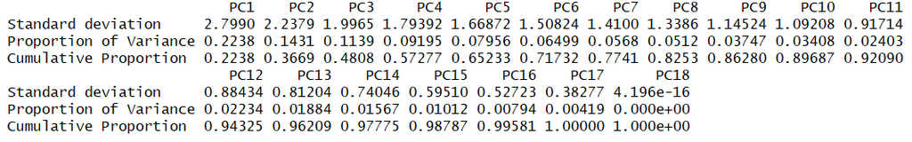

## Table 4

PCA loadings for the four firsts PCs explaining pesticides contribution of the main sources contamination of data variance.

|  | PC1 | PC2 | PC3 | PC4 |
| --- | --- | --- | --- | --- |
| 2,4-D | -0.043 | -0.260 | -0.045 | -0.158 |
| 4,4'-DDD | 0.119 | -0.118 | 0.003 | -0.066 |
| Acetamiprid | 0.028 | 0.045 | 0.100 | -0.008 |
| Alachlor | -0.253 | 0.106 | -0.201 | -0.086 |
| Atrazine | 0.128 | 0.094 | -0.069 | 0.060 |
| Azinphos ethyl | -0.216 | 0.043 | 0.257 | 0.208 |
| Bentazone | 0.067 | -0.267 | -0.041 | 0.096 |
| Chlorfenviphos | -0.301 | -0.051 | 0.175 | 0.006 |
| Chlorpyrifos | 0.226 | -0.152 | -0.066 | 0.067 |
| Chlortoluron | 0.106 | 0.233 | -0.107 | 0.103 |
| Diazinon | -0.295 | -0.020 | 0.160 | -0.028 |
| Dicofol | 0.095 | -0.184 | -0.161 | 0.118 |
| Diflufenican | -0.178 | -0.072 | 0.114 | 0.237 |
| Diuron | -0.045 | -0.176 | 0.180 | -0.203 |
| Fenthion oxon | -0.112 | -0.125 | -0.065 | -0.383 |
| Fenthion oxon sulfoxide | -0.180 | 0.123 | -0.245 | -0.281 |
| Fenthion sulfoxide | -0.070 | 0.015 | 0.220 | -0.139 |
| Imidacloprid | -0.215 | -0.137 | -0.045 | 0.251 |
| Cybutrine | 0.230 | 0.100 | 0.234 | 0.020 |
| Isoproturon | -0.032 | 0.063 | 0.302 | -0.137 |
| Linuron | -0.208 | 0.139 | -0.213 | -0.246 |
| Malaoxon | -0.083 | 0.063 | 0.412 | -0.119 |
| MCPA | -0.119 | -0.199 | -0.142 | 0.278 |
| Methiocarb | -0.222 | 0.110 | 0.265 | 0.038 |
| Metolachlor | 0.006 | 0.351 | -0.080 | 0.042 |
| Molinate | 0.050 | -0.342 | 0.048 | -0.111 |
| Oxadiazon | -0.115 | -0.303 | -0.067 | -0.119 |
| Pendimethalin | 0.168 | -0.081 | 0.193 | -0.050 |
| Propanil | -0.229 | -0.100 | -0.158 | 0.266 |
| Simazine | 0.029 | -0.194 | 0.012 | -0.372 |
| Terbuthylazine | 0.134 | 0.329 | 0.048 | -0.124 |
| Terbutryn | -0.294 | 0.002 | 0.092 | 0.060 |
| Thiacloprid | -0.168 | 0.177 | -0.265 | -0.137 |
| Triadimefon | -0.049 | -0.057 | -0.076 | -0.147 |
| Triallate | 0.272 | -0.068 | 0.058 | -0.011 |

## Table 5

PCA scores for the four firsts PCs describes the contribution of contamination sources in the samples.

|  | PC1 | PC2 | PC3 | PC4 |
| --- | --- | --- | --- | --- |
| FCD1 | -2.061 | 1.209 | 4.013 | 1.305 |
| FCD2 | -0.989 | 1.268 | 4.829 | -1.769 |
| FCD3 | 0.758 | 0.971 | 0.397 | -0.613 |
| FCD4 | 2.708 | -1.361 | -0.448 | 0.026 |
| FCD5 | 3.724 | -2.374 | 0.056 | -0.852 |
| FCD6 | 2.143 | 0.676 | 0.874 | 0.016 |
| FCD7 | 2.952 | -0.518 | -0.344 | -0.029 |
| FCE1 | 2.799 | 2.420 | 0.200 | 0.274 |
| FCE2 | 3.392 | 3.259 | -1.051 | 1.420 |
| ACD1 | -6.698 | -0.153 | -0.769 | 3.251 |
| ACD2 | -4.333 | 2.923 | -3.520 | -4.423 |
| ACD3 | -2.342 | -0.881 | 1.829 | -1.184 |
| ACD4 | -1.991 | -1.994 | 0.110 | 0.408 |
| ACD5 | -0.166 | -4.970 | -0.415 | -2.661 |
| ACD6 | -0.274 | -1.146 | -1.167 | 1.970 |
| ACD7 | 0.065 | -1.356 | -0.792 | 1.116 |
| ACE1 | 0.550 | 3.583 | -1.567 | 0.081 |
| ACE2 | -0.237 | -1.556 | -2.235 | 1.665 |

# Figures

## Figure 1

Correlation plot of pesticide in watters from Ebro river Delta. Red spots indicates significant positive correlation and blue ones, negative corelation. The larger the dot, the stronger the correlation..

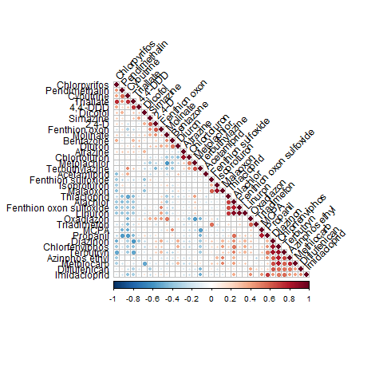

## Figure 2

Network plot correlations among pesticides analysed. Green connectors lines represent the strongest significative correlations.

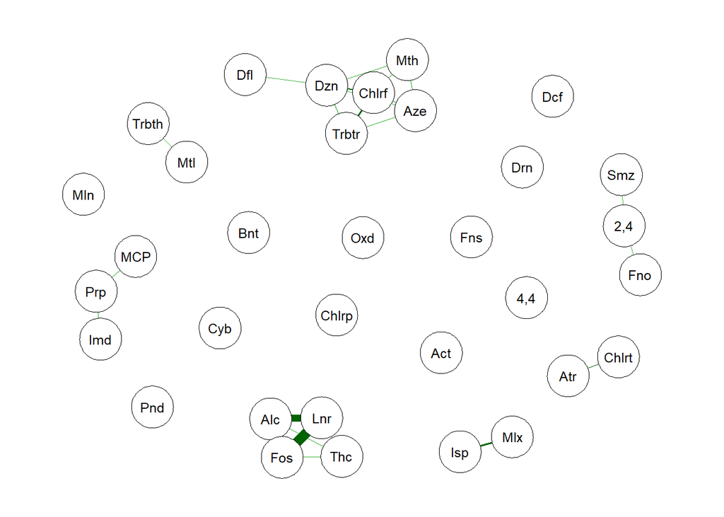

## Figure 3

Pesticides top ten ranked cross-correlations.

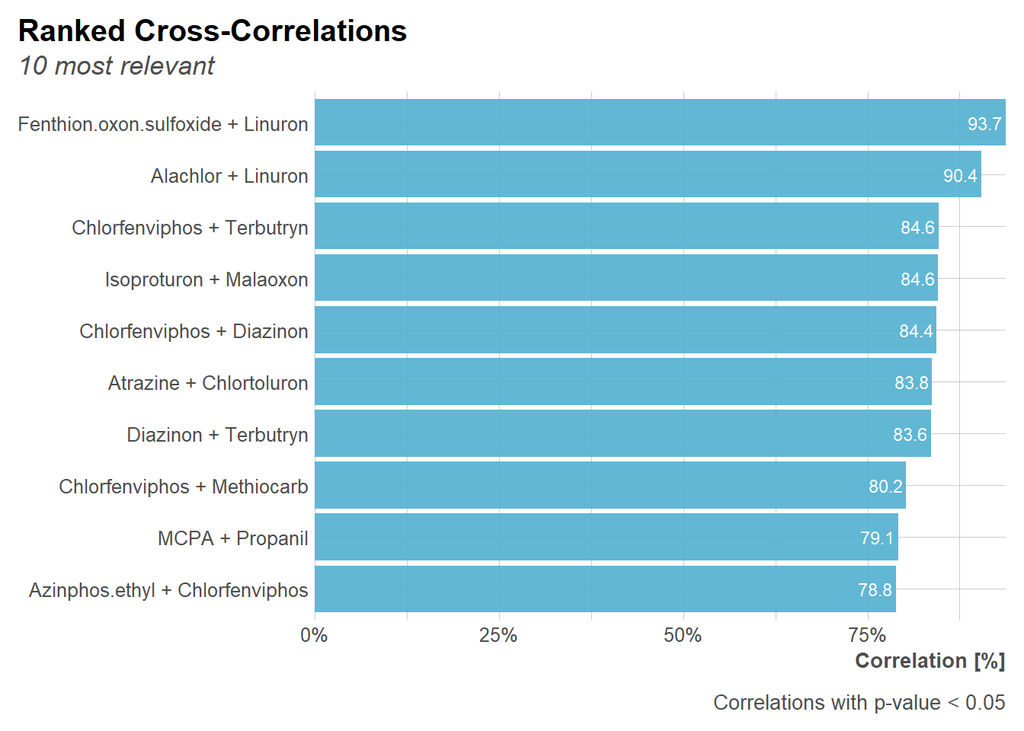

## Figure 4

Loading plots of the main contamination patterns identified by PCA for pesticides in the Ebro river delta and explained variances for each PC.

[figure not shown]

## Figure 5

PCA biplot of all analysed pesticides in Ebro river delta. a) PCA biplot for first and second PCs. b) PCA biplot for third and fourth PCs.

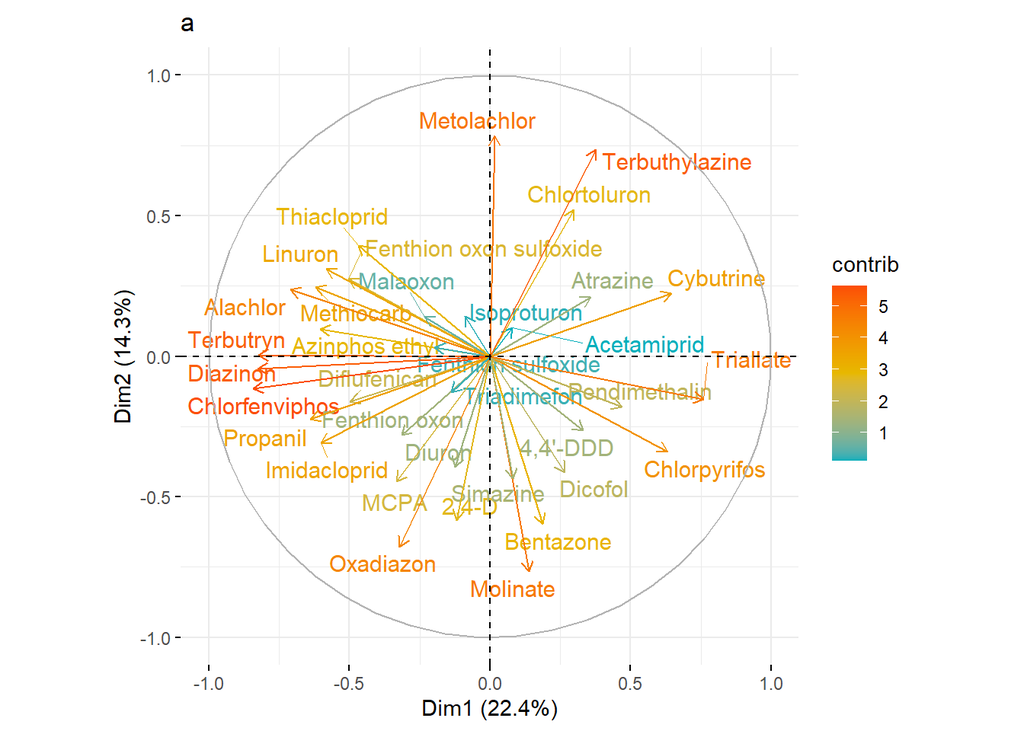

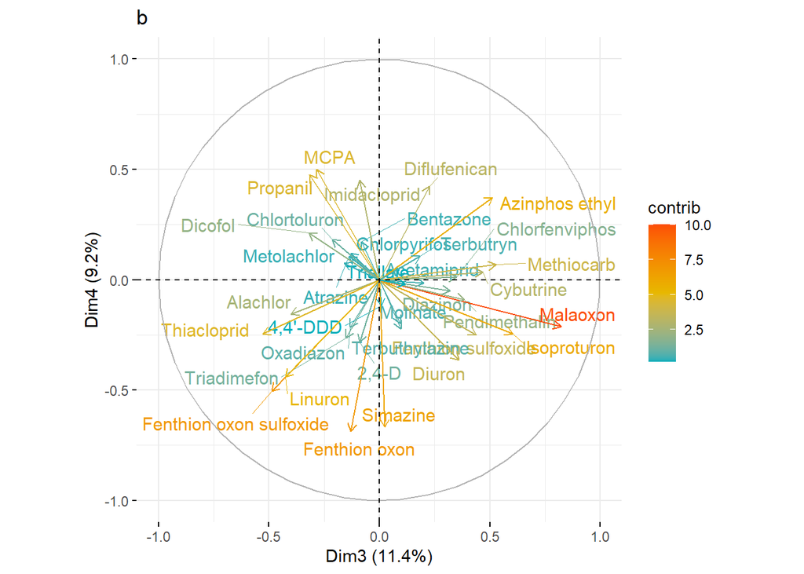

## Figure 6

Scores plot of the first (a) and second (b) contamination pattern showing the spatial distribution of pesticide pollution.

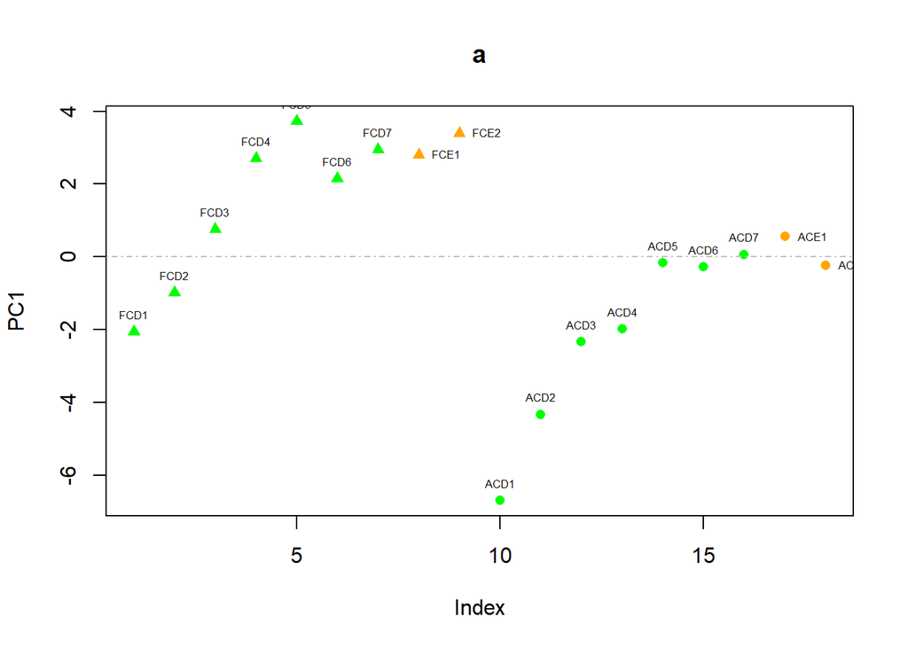

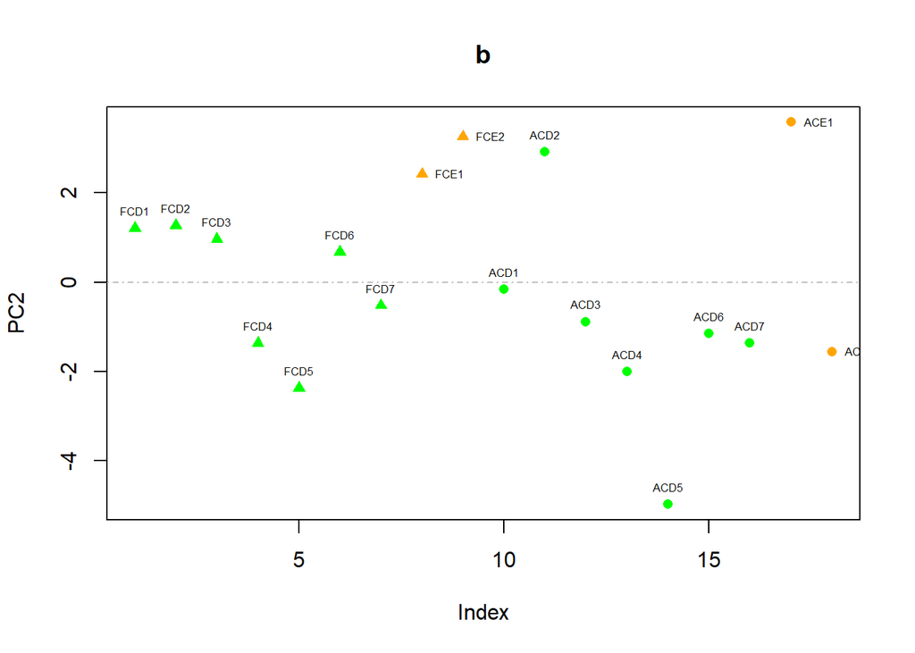

## Figure 7

PCA biplot of amilides, organophosphates, triazines and acidics pesticides in Ebro river delta. a) PCA biplot for first and second PCs. b) PCA biplot for third and fourth PCs.

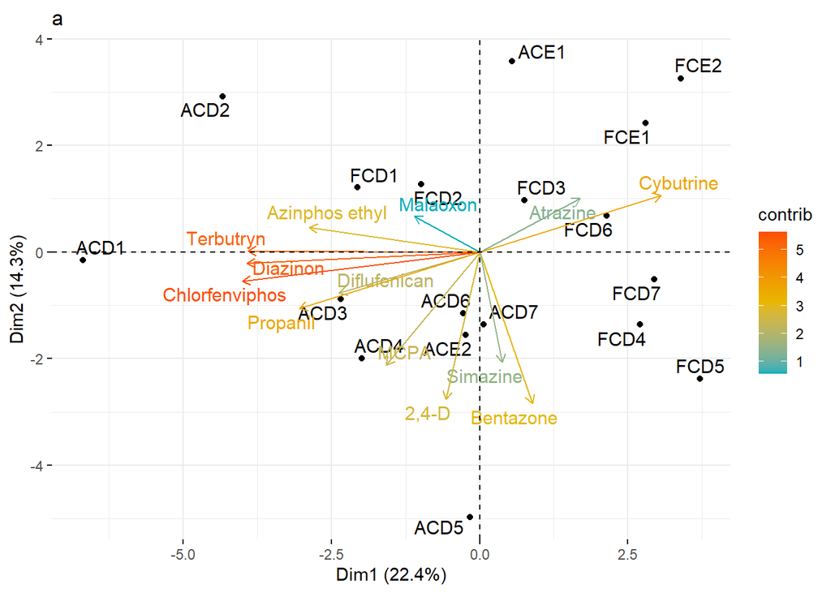

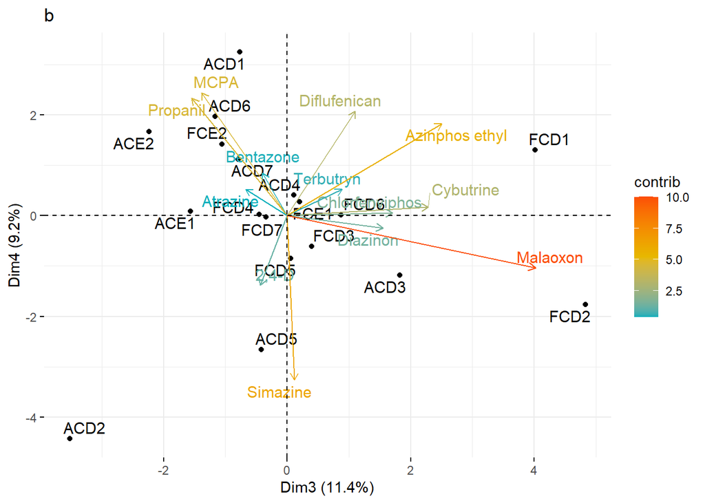